# Risk Factor Analysis

## Outcome Variable

**Outcome Variable:** sstunted

## Predictor Variables

**Intervention Variable:** enwast

**Adjustment Set:**

- arm
- sex
- W_mage
- meducyrs
- feducyrs
- vagbrth
- single
- brthmon
- W_parity
- delta_W_mage
- delta_meducyrs
- delta_feducyrs
- delta_vagbrth
- delta_single
- delta_brthmon
- delta_W_parity

## Stratifying Variables

The analysis was stratified on these variable(s):

- agecat
- studyid
- country

## Data Summary

| agecat | studyid | country | enwast | sstunted | n_cell | n |
| --- | --- | --- | --- | --- | --- | --- |
| Birth | ki0047075b-MAL-ED | BANGLADESH | 0 | 0 | 178 | 215 |
| Birth | ki0047075b-MAL-ED | BANGLADESH | 0 | 1 | 1 | 215 |
| Birth | ki0047075b-MAL-ED | BANGLADESH | 1 | 0 | 36 | 215 |
| Birth | ki0047075b-MAL-ED | BANGLADESH | 1 | 1 | 0 | 215 |
| Birth | ki0047075b-MAL-ED | BRAZIL | 0 | 0 | 59 | 62 |
| Birth | ki0047075b-MAL-ED | BRAZIL | 0 | 1 | 1 | 62 |
| Birth | ki0047075b-MAL-ED | BRAZIL | 1 | 0 | 2 | 62 |
| Birth | ki0047075b-MAL-ED | BRAZIL | 1 | 1 | 0 | 62 |
| Birth | ki0047075b-MAL-ED | INDIA | 0 | 0 | 40 | 45 |
| Birth | ki0047075b-MAL-ED | INDIA | 0 | 1 | 0 | 45 |
| Birth | ki0047075b-MAL-ED | INDIA | 1 | 0 | 5 | 45 |
| Birth | ki0047075b-MAL-ED | INDIA | 1 | 1 | 0 | 45 |
| Birth | ki0047075b-MAL-ED | NEPAL | 0 | 0 | 24 | 26 |
| Birth | ki0047075b-MAL-ED | NEPAL | 0 | 1 | 0 | 26 |
| Birth | ki0047075b-MAL-ED | NEPAL | 1 | 0 | 2 | 26 |
| Birth | ki0047075b-MAL-ED | NEPAL | 1 | 1 | 0 | 26 |
| Birth | ki0047075b-MAL-ED | PERU | 0 | 0 | 222 | 228 |
| Birth | ki0047075b-MAL-ED | PERU | 0 | 1 | 1 | 228 |
| Birth | ki0047075b-MAL-ED | PERU | 1 | 0 | 5 | 228 |
| Birth | ki0047075b-MAL-ED | PERU | 1 | 1 | 0 | 228 |
| Birth | ki0047075b-MAL-ED | SOUTH AFRICA | 0 | 0 | 108 | 121 |
| Birth | ki0047075b-MAL-ED | SOUTH AFRICA | 0 | 1 | 0 | 121 |
| Birth | ki0047075b-MAL-ED | SOUTH AFRICA | 1 | 0 | 13 | 121 |
| Birth | ki0047075b-MAL-ED | SOUTH AFRICA | 1 | 1 | 0 | 121 |
| Birth | ki0047075b-MAL-ED | TANZANIA, UNITED REPUBLIC OF | 0 | 0 | 114 | 115 |
| Birth | ki0047075b-MAL-ED | TANZANIA, UNITED REPUBLIC OF | 0 | 1 | 0 | 115 |
| Birth | ki0047075b-MAL-ED | TANZANIA, UNITED REPUBLIC OF | 1 | 0 | 1 | 115 |
| Birth | ki0047075b-MAL-ED | TANZANIA, UNITED REPUBLIC OF | 1 | 1 | 0 | 115 |
| Birth | ki1000108-CMC-V-BCS-2002 | INDIA | 0 | 0 | 75 | 87 |
| Birth | ki1000108-CMC-V-BCS-2002 | INDIA | 0 | 1 | 0 | 87 |

[output cut: 298 more lines]

The following strata were considered:

- agecat: 24 months, studyid: ki0047075b-MAL-ED, country: BANGLADESH
- agecat: 24 months, studyid: ki0047075b-MAL-ED, country: BRAZIL
- agecat: 24 months, studyid: ki0047075b-MAL-ED, country: INDIA
- agecat: 24 months, studyid: ki0047075b-MAL-ED, country: NEPAL
- agecat: 24 months, studyid: ki0047075b-MAL-ED, country: PERU
- agecat: 24 months, studyid: ki0047075b-MAL-ED, country: SOUTH AFRICA
- agecat: 24 months, studyid: ki0047075b-MAL-ED, country: TANZANIA, UNITED REPUBLIC OF
- agecat: 24 months, studyid: ki1000108-CMC-V-BCS-2002, country: INDIA
- agecat: 24 months, studyid: ki1000108-IRC, country: INDIA
- agecat: 24 months, studyid: ki1000109-EE, country: PAKISTAN
- agecat: 24 months, studyid: ki1017093-NIH-Birth, country: BANGLADESH
- agecat: 24 months, studyid: ki1017093b-PROVIDE, country: BANGLADESH
- agecat: 24 months, studyid: ki1017093c-NIH-Crypto, country: BANGLADESH
- agecat: 24 months, studyid: ki1066203-TanzaniaChild2, country: TANZANIA, UNITED REPUBLIC OF
- agecat: 24 months, studyid: ki1101329-Keneba, country: GAMBIA
- agecat: 24 months, studyid: ki1113344-GMS-Nepal, country: NEPAL
- agecat: 24 months, studyid: ki1114097-CMIN, country: BANGLADESH
- agecat: 24 months, studyid: ki1114097-CONTENT, country: PERU
- agecat: 24 months, studyid: ki1119695-PROBIT, country: BELARUS
- agecat: 24 months, studyid: ki1126311-ZVITAMBO, country: ZIMBABWE
- agecat: 24 months, studyid: ki1135781-COHORTS, country: GUATEMALA
- agecat: 24 months, studyid: ki1135781-COHORTS, country: INDIA
- agecat: 24 months, studyid: ki1135781-COHORTS, country: PHILIPPINES
- agecat: 24 months, studyid: ki1148112-LCNI-5, country: MALAWI
- agecat: 24 months, studyid: kiGH5241-JiVitA-3, country: BANGLADESH
- agecat: 24 months, studyid: kiGH5241-JiVitA-4, country: BANGLADESH
- agecat: 6 months, studyid: ki0047075b-MAL-ED, country: BANGLADESH
- agecat: 6 months, studyid: ki0047075b-MAL-ED, country: BRAZIL
- agecat: 6 months, studyid: ki0047075b-MAL-ED, country: INDIA
- agecat: 6 months, studyid: ki0047075b-MAL-ED, country: NEPAL
- agecat: 6 months, studyid: ki0047075b-MAL-ED, country: PERU
- agecat: 6 months, studyid: ki0047075b-MAL-ED, country: SOUTH AFRICA
- agecat: 6 months, studyid: ki0047075b-MAL-ED, country: TANZANIA, UNITED REPUBLIC OF
- agecat: 6 months, studyid: ki1000108-CMC-V-BCS-2002, country: INDIA
- agecat: 6 months, studyid: ki1000108-IRC, country: INDIA
- agecat: 6 months, studyid: ki1000109-EE, country: PAKISTAN
- agecat: 6 months, studyid: ki1000109-ResPak, country: PAKISTAN
- agecat: 6 months, studyid: ki1000304b-SAS-CompFeed, country: INDIA
- agecat: 6 months, studyid: ki1000304b-SAS-FoodSuppl, country: INDIA
- agecat: 6 months, studyid: ki1017093-NIH-Birth, country: BANGLADESH
- agecat: 6 months, studyid: ki1017093b-PROVIDE, country: BANGLADESH
- agecat: 6 months, studyid: ki1017093c-NIH-Crypto, country: BANGLADESH
- agecat: 6 months, studyid: ki1066203-TanzaniaChild2, country: TANZANIA, UNITED REPUBLIC OF
- agecat: 6 months, studyid: ki1101329-Keneba, country: GAMBIA
- agecat: 6 months, studyid: ki1112895-Guatemala BSC, country: GUATEMALA
- agecat: 6 months, studyid: ki1113344-GMS-Nepal, country: NEPAL
- agecat: 6 months, studyid: ki1114097-CMIN, country: BANGLADESH
- agecat: 6 months, studyid: ki1114097-CONTENT, country: PERU
- agecat: 6 months, studyid: ki1119695-PROBIT, country: BELARUS
- agecat: 6 months, studyid: ki1126311-ZVITAMBO, country: ZIMBABWE
- agecat: 6 months, studyid: ki1135781-COHORTS, country: GUATEMALA
- agecat: 6 months, studyid: ki1135781-COHORTS, country: INDIA
- agecat: 6 months, studyid: ki1135781-COHORTS, country: PHILIPPINES
- agecat: 6 months, studyid: ki1148112-LCNI-5, country: MALAWI
- agecat: 6 months, studyid: kiGH5241-JiVitA-3, country: BANGLADESH
- agecat: 6 months, studyid: kiGH5241-JiVitA-4, country: BANGLADESH
- agecat: Birth, studyid: ki0047075b-MAL-ED, country: BANGLADESH
- agecat: Birth, studyid: ki0047075b-MAL-ED, country: BRAZIL
- agecat: Birth, studyid: ki0047075b-MAL-ED, country: INDIA
- agecat: Birth, studyid: ki0047075b-MAL-ED, country: NEPAL
- agecat: Birth, studyid: ki0047075b-MAL-ED, country: PERU
- agecat: Birth, studyid: ki0047075b-MAL-ED, country: SOUTH AFRICA
- agecat: Birth, studyid: ki0047075b-MAL-ED, country: TANZANIA, UNITED REPUBLIC OF
- agecat: Birth, studyid: ki1000108-CMC-V-BCS-2002, country: INDIA
- agecat: Birth, studyid: ki1000108-IRC, country: INDIA
- agecat: Birth, studyid: ki1000109-EE, country: PAKISTAN
- agecat: Birth, studyid: ki1000109-ResPak, country: PAKISTAN
- agecat: Birth, studyid: ki1000304b-SAS-CompFeed, country: INDIA
- agecat: Birth, studyid: ki1017093-NIH-Birth, country: BANGLADESH
- agecat: Birth, studyid: ki1017093b-PROVIDE, country: BANGLADESH
- agecat: Birth, studyid: ki1017093c-NIH-Crypto, country: BANGLADESH
- agecat: Birth, studyid: ki1101329-Keneba, country: GAMBIA
- agecat: Birth, studyid: ki1113344-GMS-Nepal, country: NEPAL
- agecat: Birth, studyid: ki1114097-CMIN, country: BANGLADESH
- agecat: Birth, studyid: ki1114097-CONTENT, country: PERU
- agecat: Birth, studyid: ki1119695-PROBIT, country: BELARUS
- agecat: Birth, studyid: ki1126311-ZVITAMBO, country: ZIMBABWE
- agecat: Birth, studyid: ki1135781-COHORTS, country: GUATEMALA
- agecat: Birth, studyid: ki1135781-COHORTS, country: INDIA
- agecat: Birth, studyid: ki1135781-COHORTS, country: PHILIPPINES
- agecat: Birth, studyid: kiGH5241-JiVitA-3, country: BANGLADESH
- agecat: Birth, studyid: kiGH5241-JiVitA-4, country: BANGLADESH

### Dropped Strata

Some strata were dropped due to rare outcomes:

- agecat: Birth, studyid: ki0047075b-MAL-ED, country: BANGLADESH
- agecat: Birth, studyid: ki0047075b-MAL-ED, country: BRAZIL
- agecat: Birth, studyid: ki0047075b-MAL-ED, country: INDIA
- agecat: Birth, studyid: ki0047075b-MAL-ED, country: NEPAL
- agecat: Birth, studyid: ki0047075b-MAL-ED, country: PERU
- agecat: Birth, studyid: ki0047075b-MAL-ED, country: SOUTH AFRICA
- agecat: Birth, studyid: ki0047075b-MAL-ED, country: TANZANIA, UNITED REPUBLIC OF
- agecat: Birth, studyid: ki1000108-CMC-V-BCS-2002, country: INDIA
- agecat: Birth, studyid: ki1000108-IRC, country: INDIA
- agecat: Birth, studyid: ki1000109-EE, country: PAKISTAN
- agecat: Birth, studyid: ki1000109-ResPak, country: PAKISTAN
- agecat: Birth, studyid: ki1000304b-SAS-CompFeed, country: INDIA
- agecat: Birth, studyid: ki1017093-NIH-Birth, country: BANGLADESH
- agecat: Birth, studyid: ki1017093b-PROVIDE, country: BANGLADESH
- agecat: Birth, studyid: ki1017093c-NIH-Crypto, country: BANGLADESH
- agecat: Birth, studyid: ki1101329-Keneba, country: GAMBIA
- agecat: Birth, studyid: ki1113344-GMS-Nepal, country: NEPAL
- agecat: Birth, studyid: ki1114097-CMIN, country: BANGLADESH
- agecat: Birth, studyid: ki1114097-CONTENT, country: PERU
- agecat: Birth, studyid: ki1119695-PROBIT, country: BELARUS
- agecat: Birth, studyid: ki1126311-ZVITAMBO, country: ZIMBABWE
- agecat: Birth, studyid: ki1135781-COHORTS, country: GUATEMALA
- agecat: Birth, studyid: ki1135781-COHORTS, country: INDIA
- agecat: Birth, studyid: ki1135781-COHORTS, country: PHILIPPINES
- agecat: Birth, studyid: kiGH5241-JiVitA-3, country: BANGLADESH
- agecat: Birth, studyid: kiGH5241-JiVitA-4, country: BANGLADESH
- agecat: 6 months, studyid: ki0047075b-MAL-ED, country: BANGLADESH
- agecat: 6 months, studyid: ki0047075b-MAL-ED, country: BRAZIL
- agecat: 6 months, studyid: ki0047075b-MAL-ED, country: INDIA
- agecat: 6 months, studyid: ki0047075b-MAL-ED, country: NEPAL
- agecat: 6 months, studyid: ki0047075b-MAL-ED, country: PERU
- agecat: 6 months, studyid: ki0047075b-MAL-ED, country: SOUTH AFRICA
- agecat: 6 months, studyid: ki0047075b-MAL-ED, country: TANZANIA, UNITED REPUBLIC OF
- agecat: 6 months, studyid: ki1066203-TanzaniaChild2, country: TANZANIA, UNITED REPUBLIC OF
- agecat: 6 months, studyid: ki1112895-Guatemala BSC, country: GUATEMALA
- agecat: 6 months, studyid: ki1113344-GMS-Nepal, country: NEPAL
- agecat: 6 months, studyid: ki1114097-CMIN, country: BANGLADESH
- agecat: 6 months, studyid: ki1114097-CONTENT, country: PERU
- agecat: 24 months, studyid: ki0047075b-MAL-ED, country: BRAZIL
- agecat: 24 months, studyid: ki0047075b-MAL-ED, country: NEPAL
- agecat: 24 months, studyid: ki0047075b-MAL-ED, country: PERU
- agecat: 24 months, studyid: ki0047075b-MAL-ED, country: SOUTH AFRICA
- agecat: 24 months, studyid: ki0047075b-MAL-ED, country: TANZANIA, UNITED REPUBLIC OF
- agecat: 24 months, studyid: ki1066203-TanzaniaChild2, country: TANZANIA, UNITED REPUBLIC OF
- agecat: 24 months, studyid: ki1114097-CONTENT, country: PERU
- agecat: 24 months, studyid: ki1148112-LCNI-5, country: MALAWI

## Methods Detail

We’re interested in the causal parameters $E[Y_a]$ for all values of $a \in \mathcal{A}$. These parameters represent the mean outcome if, possibly contrary to fact, we intervened to set all units to have $A=a$. Under the randomization and positivity assumptions, these are identified by the statistical parameters $\psi_a=E_W[E_{Y|A,W}(Y|A=a,W)]$. In addition, we’re interested in the mean of $Y$, $E[Y]$ under no intervention (the observed mean). We will estimate these parameters by using SuperLearner to fit the relevant likelihood factors – $E_{Y|A,W}(Y|A=a,W)$ and $p(A=a|W)$, and then updating our likelihood fit using a joint TMLE.

For unadjusted analyses ($W=\{\}$), initial likelihoods were estimated using Lrnr_glm to estimate the simple $E(Y|A)$ and Lrnr_mean to estimate $p(A)$. For adjusted analyses, a small library containing Lrnr_glmnet, Lrnr_xgboost, and Lrnr_mean was used.

Having estimated these parameters, we will then use the delta method to estimate relative risks and attributable risks relative to a prespecified baseline level of $A$.

# Results Detail

## Results Plots

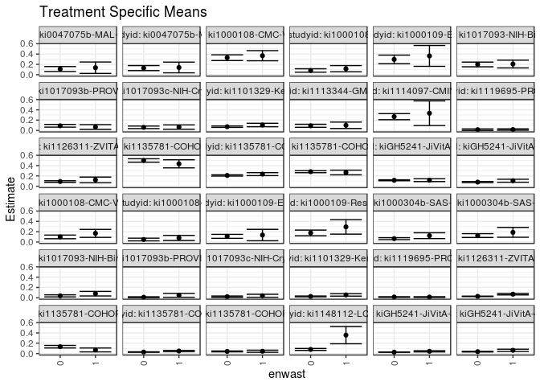

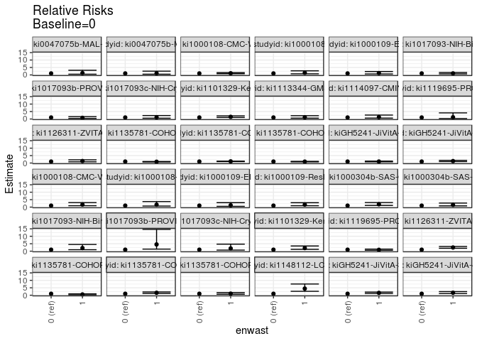

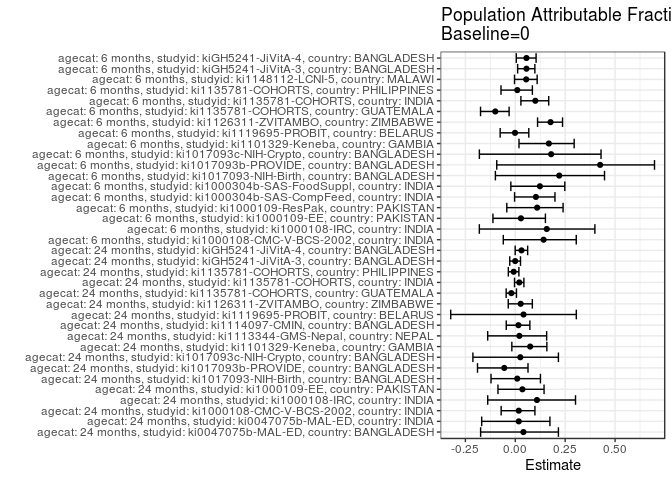

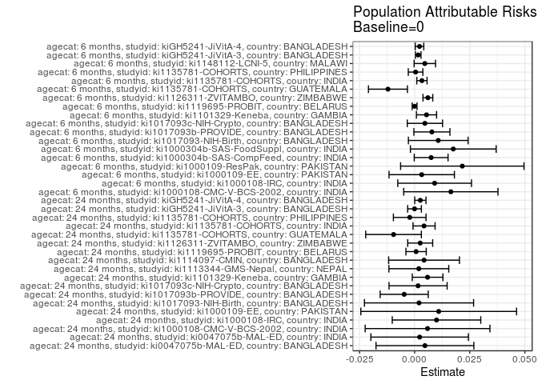

## Results Table

### Parameter: TSM

| agecat | studyid | country | intervention_level | baseline_level | estimate | ci_lower | ci_upper |
| --- | --- | --- | --- | --- | --- | --- | --- |
| 6 months | ki1000108-CMC-V-BCS-2002 | INDIA | 0 | NA | 0.0992730 | 0.0636280 | 0.1349181 |
| 6 months | ki1000108-CMC-V-BCS-2002 | INDIA | 1 | NA | 0.1676700 | 0.0902702 | 0.2450698 |
| 6 months | ki1000108-IRC | INDIA | 0 | NA | 0.0485075 | 0.0227527 | 0.0742622 |
| 6 months | ki1000108-IRC | INDIA | 1 | NA | 0.0789474 | 0.0293823 | 0.1285125 |
| 6 months | ki1000109-EE | PAKISTAN | 0 | NA | 0.1098039 | 0.0713647 | 0.1482432 |
| 6 months | ki1000109-EE | PAKISTAN | 1 | NA | 0.1351351 | 0.0247907 | 0.2454796 |
| 6 months | ki1000109-ResPak | PAKISTAN | 0 | NA | 0.1757422 | 0.1207482 | 0.2307362 |
| 6 months | ki1000109-ResPak | PAKISTAN | 1 | NA | 0.2930481 | 0.1528251 | 0.4332710 |
| 6 months | ki1000304b-SAS-CompFeed | INDIA | 0 | NA | 0.0650528 | 0.0461089 | 0.0839968 |
| 6 months | ki1000304b-SAS-CompFeed | INDIA | 1 | NA | 0.1225237 | 0.0661569 | 0.1788905 |
| 6 months | ki1000304b-SAS-FoodSuppl | INDIA | 0 | NA | 0.1245679 | 0.0876461 | 0.1614897 |
| 6 months | ki1000304b-SAS-FoodSuppl | INDIA | 1 | NA | 0.1875055 | 0.0920353 | 0.2829756 |
| 6 months | ki1017093-NIH-Birth | BANGLADESH | 0 | NA | 0.0379250 | 0.0181139 | 0.0577361 |
| 6 months | ki1017093-NIH-Birth | BANGLADESH | 1 | NA | 0.0797028 | 0.0353709 | 0.1240346 |
| 6 months | ki1017093b-PROVIDE | BANGLADESH | 0 | NA | 0.0105932 | 0.0013496 | 0.0198369 |
| 6 months | ki1017093b-PROVIDE | BANGLADESH | 1 | NA | 0.0480000 | 0.0104944 | 0.0855056 |
| 6 months | ki1017093c-NIH-Crypto | BANGLADESH | 0 | NA | 0.0212766 | 0.0088287 | 0.0337245 |
| 6 months | ki1017093c-NIH-Crypto | BANGLADESH | 1 | NA | 0.0395480 | 0.0108154 | 0.0682806 |
| 6 months | ki1101329-Keneba | GAMBIA | 0 | NA | 0.0266465 | 0.0188543 | 0.0344388 |
| 6 months | ki1101329-Keneba | GAMBIA | 1 | NA | 0.0556765 | 0.0324850 | 0.0788680 |
| 6 months | ki1119695-PROBIT | BELARUS | 0 | NA | 0.0153197 | 0.0095952 | 0.0210442 |
| 6 months | ki1119695-PROBIT | BELARUS | 1 | NA | 0.0139897 | 0.0075015 | 0.0204779 |
| 6 months | ki1126311-ZVITAMBO | ZIMBABWE | 0 | NA | 0.0280036 | 0.0241071 | 0.0319001 |
| 6 months | ki1126311-ZVITAMBO | ZIMBABWE | 1 | NA | 0.0697052 | 0.0557336 | 0.0836767 |
| 6 months | ki1135781-COHORTS | GUATEMALA | 0 | NA | 0.1330918 | 0.1083538 | 0.1578299 |
| 6 months | ki1135781-COHORTS | GUATEMALA | 1 | NA | 0.0700111 | 0.0325209 | 0.1075013 |
| 6 months | ki1135781-COHORTS | INDIA | 0 | NA | 0.0295771 | 0.0250366 | 0.0341176 |
| 6 months | ki1135781-COHORTS | INDIA | 1 | NA | 0.0490380 | 0.0365241 | 0.0615518 |
| 6 months | ki1135781-COHORTS | PHILIPPINES | 0 | NA | 0.0416089 | 0.0332522 | 0.0499655 |
| 6 months | ki1135781-COHORTS | PHILIPPINES | 1 | NA | 0.0450908 | 0.0247510 | 0.0654306 |
| 6 months | ki1148112-LCNI-5 | MALAWI | 0 | NA | 0.0800000 | 0.0613187 | 0.0986813 |
| 6 months | ki1148112-LCNI-5 | MALAWI | 1 | NA | 0.3571429 | 0.1895146 | 0.5247712 |
| 6 months | kiGH5241-JiVitA-3 | BANGLADESH | 0 | NA | 0.0274380 | 0.0243697 | 0.0305063 |
| 6 months | kiGH5241-JiVitA-3 | BANGLADESH | 1 | NA | 0.0436771 | 0.0320083 | 0.0553458 |
| 6 months | kiGH5241-JiVitA-4 | BANGLADESH | 0 | NA | 0.0372472 | 0.0312620 | 0.0432323 |
| 6 months | kiGH5241-JiVitA-4 | BANGLADESH | 1 | NA | 0.0628628 | 0.0411931 | 0.0845325 |
| 24 months | ki0047075b-MAL-ED | BANGLADESH | 0 | NA | 0.1097561 | 0.0617962 | 0.1577160 |
| 24 months | ki0047075b-MAL-ED | BANGLADESH | 1 | NA | 0.1351351 | 0.0247048 | 0.2455655 |
| 24 months | ki0047075b-MAL-ED | INDIA | 0 | NA | 0.1277778 | 0.0788980 | 0.1766575 |
| 24 months | ki0047075b-MAL-ED | INDIA | 1 | NA | 0.1395349 | 0.0357348 | 0.2433350 |
| 24 months | ki1000108-CMC-V-BCS-2002 | INDIA | 0 | NA | 0.3293054 | 0.2734968 | 0.3851140 |
| 24 months | ki1000108-CMC-V-BCS-2002 | INDIA | 1 | NA | 0.3679113 | 0.2697785 | 0.4660440 |
| 24 months | ki1000108-IRC | INDIA | 0 | NA | 0.0814620 | 0.0485792 | 0.1143447 |
| 24 months | ki1000108-IRC | INDIA | 1 | NA | 0.1159554 | 0.0558250 | 0.1760858 |
| 24 months | ki1000109-EE | PAKISTAN | 0 | NA | 0.2956522 | 0.2119428 | 0.3793616 |
| 24 months | ki1000109-EE | PAKISTAN | 1 | NA | 0.3636364 | 0.1618862 | 0.5653865 |
| 24 months | ki1017093-NIH-Birth | BANGLADESH | 0 | NA | 0.1984958 | 0.1527432 | 0.2442483 |
| 24 months | ki1017093-NIH-Birth | BANGLADESH | 1 | NA | 0.2059403 | 0.1310236 | 0.2808569 |
| 24 months | ki1017093b-PROVIDE | BANGLADESH | 0 | NA | 0.0907080 | 0.0642087 | 0.1172073 |
| 24 months | ki1017093b-PROVIDE | BANGLADESH | 1 | NA | 0.0677966 | 0.0223975 | 0.1131958 |
| 24 months | ki1017093c-NIH-Crypto | BANGLADESH | 0 | NA | 0.0604396 | 0.0359345 | 0.0849446 |
| 24 months | ki1017093c-NIH-Crypto | BANGLADESH | 1 | NA | 0.0661765 | 0.0243552 | 0.1079978 |
| 24 months | ki1101329-Keneba | GAMBIA | 0 | NA | 0.0728334 | 0.0590428 | 0.0866240 |
| 24 months | ki1101329-Keneba | GAMBIA | 1 | NA | 0.1056582 | 0.0721278 | 0.1391885 |
| 24 months | ki1113344-GMS-Nepal | NEPAL | 0 | NA | 0.0904110 | 0.0609591 | 0.1198628 |
| 24 months | ki1113344-GMS-Nepal | NEPAL | 1 | NA | 0.1000000 | 0.0379523 | 0.1620477 |
| 24 months | ki1114097-CMIN | BANGLADESH | 0 | NA | 0.2672811 | 0.2082734 | 0.3262889 |
| 24 months | ki1114097-CMIN | BANGLADESH | 1 | NA | 0.3333333 | 0.0942583 | 0.5724084 |
| 24 months | ki1119695-PROBIT | BELARUS | 0 | NA | 0.0152144 | 0.0005501 | 0.0298788 |
| 24 months | ki1119695-PROBIT | BELARUS | 1 | NA | 0.0173997 | 0.0042374 | 0.0305619 |
| 24 months | ki1126311-ZVITAMBO | ZIMBABWE | 0 | NA | 0.0911583 | 0.0757030 | 0.1066137 |
| 24 months | ki1126311-ZVITAMBO | ZIMBABWE | 1 | NA | 0.1227274 | 0.0679583 | 0.1774964 |
| 24 months | ki1135781-COHORTS | GUATEMALA | 0 | NA | 0.4993522 | 0.4662239 | 0.5324804 |
| 24 months | ki1135781-COHORTS | GUATEMALA | 1 | NA | 0.4339265 | 0.3553880 | 0.5124651 |
| 24 months | ki1135781-COHORTS | INDIA | 0 | NA | 0.2091443 | 0.1969271 | 0.2213616 |
| 24 months | ki1135781-COHORTS | INDIA | 1 | NA | 0.2345715 | 0.2056789 | 0.2634642 |
| 24 months | ki1135781-COHORTS | PHILIPPINES | 0 | NA | 0.2821613 | 0.2623672 | 0.3019554 |
| 24 months | ki1135781-COHORTS | PHILIPPINES | 1 | NA | 0.2664935 | 0.2210917 | 0.3118954 |
| 24 months | kiGH5241-JiVitA-3 | BANGLADESH | 0 | NA | 0.1156250 | 0.1066501 | 0.1246000 |
| 24 months | kiGH5241-JiVitA-3 | BANGLADESH | 1 | NA | 0.1172708 | 0.0900883 | 0.1444532 |
| 24 months | kiGH5241-JiVitA-4 | BANGLADESH | 0 | NA | 0.0801481 | 0.0701925 | 0.0901036 |
| 24 months | kiGH5241-JiVitA-4 | BANGLADESH | 1 | NA | 0.1065081 | 0.0775263 | 0.1354898 |

### Parameter: E(Y)

| agecat | studyid | country | intervention_level | baseline_level | estimate | ci_lower | ci_upper |
| --- | --- | --- | --- | --- | --- | --- | --- |
| 6 months | ki1000108-CMC-V-BCS-2002 | INDIA | NA | NA | 0.1157025 | 0.0827518 | 0.1486532 |
| 6 months | ki1000108-IRC | INDIA | NA | NA | 0.0575916 | 0.0341987 | 0.0809846 |
| 6 months | ki1000109-EE | PAKISTAN | NA | NA | 0.1130137 | 0.0766368 | 0.1493906 |
| 6 months | ki1000109-ResPak | PAKISTAN | NA | NA | 0.1973684 | 0.1455920 | 0.2491449 |
| 6 months | ki1000304b-SAS-CompFeed | INDIA | NA | NA | 0.0725474 | 0.0527677 | 0.0923271 |
| 6 months | ki1000304b-SAS-FoodSuppl | INDIA | NA | NA | 0.1421053 | 0.1069532 | 0.1772573 |
| 6 months | ki1017093-NIH-Birth | BANGLADESH | NA | NA | 0.0486381 | 0.0300237 | 0.0672526 |
| 6 months | ki1017093b-PROVIDE | BANGLADESH | NA | NA | 0.0184255 | 0.0076286 | 0.0292223 |
| 6 months | ki1017093c-NIH-Crypto | BANGLADESH | NA | NA | 0.0259366 | 0.0141026 | 0.0377706 |
| 6 months | ki1101329-Keneba | GAMBIA | NA | NA | 0.0320355 | 0.0243714 | 0.0396996 |
| 6 months | ki1119695-PROBIT | BELARUS | NA | NA | 0.0152977 | 0.0100190 | 0.0205764 |
| 6 months | ki1126311-ZVITAMBO | ZIMBABWE | NA | NA | 0.0340103 | 0.0300807 | 0.0379399 |
| 6 months | ki1135781-COHORTS | GUATEMALA | NA | NA | 0.1209767 | 0.0996719 | 0.1422815 |
| 6 months | ki1135781-COHORTS | INDIA | NA | NA | 0.0328826 | 0.0285497 | 0.0372155 |
| 6 months | ki1135781-COHORTS | PHILIPPINES | NA | NA | 0.0420363 | 0.0343109 | 0.0497616 |
| 6 months | ki1148112-LCNI-5 | MALAWI | NA | NA | 0.0846246 | 0.0657805 | 0.1034686 |
| 6 months | kiGH5241-JiVitA-3 | BANGLADESH | NA | NA | 0.0290649 | 0.0261073 | 0.0320225 |
| 6 months | kiGH5241-JiVitA-4 | BANGLADESH | NA | NA | 0.0394558 | 0.0337069 | 0.0452047 |
| 24 months | ki0047075b-MAL-ED | BANGLADESH | NA | NA | 0.1144279 | 0.0703104 | 0.1585454 |
| 24 months | ki0047075b-MAL-ED | INDIA | NA | NA | 0.1300448 | 0.0857996 | 0.1742901 |
| 24 months | ki1000108-CMC-V-BCS-2002 | INDIA | NA | NA | 0.3351648 | 0.2866046 | 0.3837251 |
| 24 months | ki1000108-IRC | INDIA | NA | NA | 0.0913838 | 0.0624876 | 0.1202800 |
| 24 months | ki1000109-EE | PAKISTAN | NA | NA | 0.3065693 | 0.2290795 | 0.3840591 |
| 24 months | ki1017093-NIH-Birth | BANGLADESH | NA | NA | 0.2004890 | 0.1616404 | 0.2393376 |
| 24 months | ki1017093b-PROVIDE | BANGLADESH | NA | NA | 0.0859649 | 0.0629328 | 0.1089970 |
| 24 months | ki1017093c-NIH-Crypto | BANGLADESH | NA | NA | 0.0620000 | 0.0408410 | 0.0831590 |
| 24 months | ki1101329-Keneba | GAMBIA | NA | NA | 0.0787120 | 0.0658197 | 0.0916043 |
| 24 months | ki1113344-GMS-Nepal | NEPAL | NA | NA | 0.0923077 | 0.0656815 | 0.1189338 |
| 24 months | ki1114097-CMIN | BANGLADESH | NA | NA | 0.2715517 | 0.2141972 | 0.3289063 |
| 24 months | ki1119695-PROBIT | BELARUS | NA | NA | 0.0158730 | 0.0044440 | 0.0273021 |
| 24 months | ki1126311-ZVITAMBO | ZIMBABWE | NA | NA | 0.0936877 | 0.0789610 | 0.1084144 |
| 24 months | ki1135781-COHORTS | GUATEMALA | NA | NA | 0.4897760 | 0.4591879 | 0.5203642 |
| 24 months | ki1135781-COHORTS | INDIA | NA | NA | 0.2134122 | 0.2021332 | 0.2246912 |
| 24 months | ki1135781-COHORTS | PHILIPPINES | NA | NA | 0.2799318 | 0.2617642 | 0.2980994 |
| 24 months | kiGH5241-JiVitA-3 | BANGLADESH | NA | NA | 0.1155758 | 0.1070958 | 0.1240558 |
| 24 months | kiGH5241-JiVitA-4 | BANGLADESH | NA | NA | 0.0827346 | 0.0732177 | 0.0922516 |

### Parameter: RR

| agecat | studyid | country | intervention_level | baseline_level | estimate | ci_lower | ci_upper |
| --- | --- | --- | --- | --- | --- | --- | --- |
| 6 months | ki1000108-CMC-V-BCS-2002 | INDIA | 0 | 0 | 1.0000000 | 1.0000000 | 1.0000000 |
| 6 months | ki1000108-CMC-V-BCS-2002 | INDIA | 1 | 0 | 1.6889780 | 0.9402369 | 3.0339659 |
| 6 months | ki1000108-IRC | INDIA | 0 | 0 | 1.0000000 | 1.0000000 | 1.0000000 |
| 6 months | ki1000108-IRC | INDIA | 1 | 0 | 1.6275303 | 0.7152181 | 3.7035625 |
| 6 months | ki1000109-EE | PAKISTAN | 0 | 0 | 1.0000000 | 1.0000000 | 1.0000000 |
| 6 months | ki1000109-EE | PAKISTAN | 1 | 0 | 1.2306950 | 0.5061877 | 2.9921906 |
| 6 months | ki1000109-ResPak | PAKISTAN | 0 | 0 | 1.0000000 | 1.0000000 | 1.0000000 |
| 6 months | ki1000109-ResPak | PAKISTAN | 1 | 0 | 1.6674881 | 0.9402447 | 2.9572266 |
| 6 months | ki1000304b-SAS-CompFeed | INDIA | 0 | 0 | 1.0000000 | 1.0000000 | 1.0000000 |
| 6 months | ki1000304b-SAS-CompFeed | INDIA | 1 | 0 | 1.8834489 | 1.1516977 | 3.0801310 |
| 6 months | ki1000304b-SAS-FoodSuppl | INDIA | 0 | 0 | 1.0000000 | 1.0000000 | 1.0000000 |
| 6 months | ki1000304b-SAS-FoodSuppl | INDIA | 1 | 0 | 1.5052470 | 0.8334691 | 2.7184794 |
| 6 months | ki1017093-NIH-Birth | BANGLADESH | 0 | 0 | 1.0000000 | 1.0000000 | 1.0000000 |
| 6 months | ki1017093-NIH-Birth | BANGLADESH | 1 | 0 | 2.1015906 | 0.9803906 | 4.5050240 |
| 6 months | ki1017093b-PROVIDE | BANGLADESH | 0 | 0 | 1.0000000 | 1.0000000 | 1.0000000 |
| 6 months | ki1017093b-PROVIDE | BANGLADESH | 1 | 0 | 4.5312000 | 1.4044963 | 14.6186030 |
| 6 months | ki1017093c-NIH-Crypto | BANGLADESH | 0 | 0 | 1.0000000 | 1.0000000 | 1.0000000 |
| 6 months | ki1017093c-NIH-Crypto | BANGLADESH | 1 | 0 | 1.8587571 | 0.7313258 | 4.7242661 |
| 6 months | ki1101329-Keneba | GAMBIA | 0 | 0 | 1.0000000 | 1.0000000 | 1.0000000 |
| 6 months | ki1101329-Keneba | GAMBIA | 1 | 0 | 2.0894476 | 1.2563008 | 3.4751163 |
| 6 months | ki1119695-PROBIT | BELARUS | 0 | 0 | 1.0000000 | 1.0000000 | 1.0000000 |
| 6 months | ki1119695-PROBIT | BELARUS | 1 | 0 | 0.9131865 | 0.6001985 | 1.3893896 |
| 6 months | ki1126311-ZVITAMBO | ZIMBABWE | 0 | 0 | 1.0000000 | 1.0000000 | 1.0000000 |
| 6 months | ki1126311-ZVITAMBO | ZIMBABWE | 1 | 0 | 2.4891497 | 1.9504413 | 3.1766483 |
| 6 months | ki1135781-COHORTS | GUATEMALA | 0 | 0 | 1.0000000 | 1.0000000 | 1.0000000 |
| 6 months | ki1135781-COHORTS | GUATEMALA | 1 | 0 | 0.5260362 | 0.2985524 | 0.9268526 |
| 6 months | ki1135781-COHORTS | INDIA | 0 | 0 | 1.0000000 | 1.0000000 | 1.0000000 |
| 6 months | ki1135781-COHORTS | INDIA | 1 | 0 | 1.6579701 | 1.2311746 | 2.2327174 |
| 6 months | ki1135781-COHORTS | PHILIPPINES | 0 | 0 | 1.0000000 | 1.0000000 | 1.0000000 |
| 6 months | ki1135781-COHORTS | PHILIPPINES | 1 | 0 | 1.0836821 | 0.6614718 | 1.7753847 |
| 6 months | ki1148112-LCNI-5 | MALAWI | 0 | 0 | 1.0000000 | 1.0000000 | 1.0000000 |
| 6 months | ki1148112-LCNI-5 | MALAWI | 1 | 0 | 4.4642857 | 2.6428796 | 7.5409592 |
| 6 months | kiGH5241-JiVitA-3 | BANGLADESH | 0 | 0 | 1.0000000 | 1.0000000 | 1.0000000 |
| 6 months | kiGH5241-JiVitA-3 | BANGLADESH | 1 | 0 | 1.5918477 | 1.1879843 | 2.1330072 |
| 6 months | kiGH5241-JiVitA-4 | BANGLADESH | 0 | 0 | 1.0000000 | 1.0000000 | 1.0000000 |
| 6 months | kiGH5241-JiVitA-4 | BANGLADESH | 1 | 0 | 1.6877201 | 1.1538056 | 2.4686993 |
| 24 months | ki0047075b-MAL-ED | BANGLADESH | 0 | 0 | 1.0000000 | 1.0000000 | 1.0000000 |
| 24 months | ki0047075b-MAL-ED | BANGLADESH | 1 | 0 | 1.2312312 | 0.4874034 | 3.1102168 |
| 24 months | ki0047075b-MAL-ED | INDIA | 0 | 0 | 1.0000000 | 1.0000000 | 1.0000000 |
| 24 months | ki0047075b-MAL-ED | INDIA | 1 | 0 | 1.0920121 | 0.4730886 | 2.5206494 |
| 24 months | ki1000108-CMC-V-BCS-2002 | INDIA | 0 | 0 | 1.0000000 | 1.0000000 | 1.0000000 |
| 24 months | ki1000108-CMC-V-BCS-2002 | INDIA | 1 | 0 | 1.1172343 | 0.8156145 | 1.5303952 |
| 24 months | ki1000108-IRC | INDIA | 0 | 0 | 1.0000000 | 1.0000000 | 1.0000000 |
| 24 months | ki1000108-IRC | INDIA | 1 | 0 | 1.4234297 | 0.7371915 | 2.7484744 |
| 24 months | ki1000109-EE | PAKISTAN | 0 | 0 | 1.0000000 | 1.0000000 | 1.0000000 |
| 24 months | ki1000109-EE | PAKISTAN | 1 | 0 | 1.2299465 | 0.6597384 | 2.2929822 |
| 24 months | ki1017093-NIH-Birth | BANGLADESH | 0 | 0 | 1.0000000 | 1.0000000 | 1.0000000 |
| 24 months | ki1017093-NIH-Birth | BANGLADESH | 1 | 0 | 1.0375046 | 0.6740209 | 1.5970066 |
| 24 months | ki1017093b-PROVIDE | BANGLADESH | 0 | 0 | 1.0000000 | 1.0000000 | 1.0000000 |
| 24 months | ki1017093b-PROVIDE | BANGLADESH | 1 | 0 | 0.7474163 | 0.3599748 | 1.5518618 |
| 24 months | ki1017093c-NIH-Crypto | BANGLADESH | 0 | 0 | 1.0000000 | 1.0000000 | 1.0000000 |
| 24 months | ki1017093c-NIH-Crypto | BANGLADESH | 1 | 0 | 1.0949198 | 0.5167665 | 2.3199053 |
| 24 months | ki1101329-Keneba | GAMBIA | 0 | 0 | 1.0000000 | 1.0000000 | 1.0000000 |
| 24 months | ki1101329-Keneba | GAMBIA | 1 | 0 | 1.4506824 | 1.0028317 | 2.0985371 |
| 24 months | ki1113344-GMS-Nepal | NEPAL | 0 | 0 | 1.0000000 | 1.0000000 | 1.0000000 |
| 24 months | ki1113344-GMS-Nepal | NEPAL | 1 | 0 | 1.1060606 | 0.5488190 | 2.2290959 |
| 24 months | ki1114097-CMIN | BANGLADESH | 0 | 0 | 1.0000000 | 1.0000000 | 1.0000000 |
| 24 months | ki1114097-CMIN | BANGLADESH | 1 | 0 | 1.2471264 | 0.5888451 | 2.6413131 |
| 24 months | ki1119695-PROBIT | BELARUS | 0 | 0 | 1.0000000 | 1.0000000 | 1.0000000 |
| 24 months | ki1119695-PROBIT | BELARUS | 1 | 0 | 1.1436275 | 0.3200540 | 4.0864468 |
| 24 months | ki1126311-ZVITAMBO | ZIMBABWE | 0 | 0 | 1.0000000 | 1.0000000 | 1.0000000 |
| 24 months | ki1126311-ZVITAMBO | ZIMBABWE | 1 | 0 | 1.3463102 | 0.8351020 | 2.1704548 |
| 24 months | ki1135781-COHORTS | GUATEMALA | 0 | 0 | 1.0000000 | 1.0000000 | 1.0000000 |
| 24 months | ki1135781-COHORTS | GUATEMALA | 1 | 0 | 0.8689790 | 0.7170538 | 1.0530932 |
| 24 months | ki1135781-COHORTS | INDIA | 0 | 0 | 1.0000000 | 1.0000000 | 1.0000000 |
| 24 months | ki1135781-COHORTS | INDIA | 1 | 0 | 1.1215774 | 0.9791858 | 1.2846754 |
| 24 months | ki1135781-COHORTS | PHILIPPINES | 0 | 0 | 1.0000000 | 1.0000000 | 1.0000000 |
| 24 months | ki1135781-COHORTS | PHILIPPINES | 1 | 0 | 0.9444723 | 0.7860620 | 1.1348061 |
| 24 months | kiGH5241-JiVitA-3 | BANGLADESH | 0 | 0 | 1.0000000 | 1.0000000 | 1.0000000 |
| 24 months | kiGH5241-JiVitA-3 | BANGLADESH | 1 | 0 | 1.0142337 | 0.7939393 | 1.2956532 |
| 24 months | kiGH5241-JiVitA-4 | BANGLADESH | 0 | 0 | 1.0000000 | 1.0000000 | 1.0000000 |
| 24 months | kiGH5241-JiVitA-4 | BANGLADESH | 1 | 0 | 1.3288913 | 0.9893426 | 1.7849753 |

### Parameter: PAR

| agecat | studyid | country | intervention_level | baseline_level | estimate | ci_lower | ci_upper |
| --- | --- | --- | --- | --- | --- | --- | --- |
| 6 months | ki1000108-CMC-V-BCS-2002 | INDIA | 0 | NA | 0.0164294 | -0.0049560 | 0.0378149 |
| 6 months | ki1000108-IRC | INDIA | 0 | NA | 0.0090842 | -0.0076438 | 0.0258121 |
| 6 months | ki1000109-EE | PAKISTAN | 0 | NA | 0.0032098 | -0.0116279 | 0.0180475 |
| 6 months | ki1000109-ResPak | PAKISTAN | 0 | NA | 0.0216262 | -0.0063700 | 0.0496224 |
| 6 months | ki1000304b-SAS-CompFeed | INDIA | 0 | NA | 0.0074946 | -0.0001790 | 0.0151681 |
| 6 months | ki1000304b-SAS-FoodSuppl | INDIA | 0 | NA | 0.0175374 | -0.0019198 | 0.0369945 |
| 6 months | ki1017093-NIH-Birth | BANGLADESH | 0 | NA | 0.0107132 | -0.0028318 | 0.0242581 |
| 6 months | ki1017093b-PROVIDE | BANGLADESH | 0 | NA | 0.0078322 | -0.0003475 | 0.0160119 |
| 6 months | ki1017093c-NIH-Crypto | BANGLADESH | 0 | NA | 0.0046600 | -0.0033482 | 0.0126682 |
| 6 months | ki1101329-Keneba | GAMBIA | 0 | NA | 0.0053890 | 0.0008120 | 0.0099660 |
| 6 months | ki1119695-PROBIT | BELARUS | 0 | NA | -0.0000220 | -0.0011205 | 0.0010766 |
| 6 months | ki1126311-ZVITAMBO | ZIMBABWE | 0 | NA | 0.0060067 | 0.0037793 | 0.0082341 |
| 6 months | ki1135781-COHORTS | GUATEMALA | 0 | NA | -0.0121151 | -0.0209636 | -0.0032667 |
| 6 months | ki1135781-COHORTS | INDIA | 0 | NA | 0.0033055 | 0.0009801 | 0.0056309 |
| 6 months | ki1135781-COHORTS | PHILIPPINES | 0 | NA | 0.0004274 | -0.0028751 | 0.0037299 |
| 6 months | ki1148112-LCNI-5 | MALAWI | 0 | NA | 0.0046246 | -0.0002290 | 0.0094781 |
| 6 months | kiGH5241-JiVitA-3 | BANGLADESH | 0 | NA | 0.0016269 | 0.0003637 | 0.0028900 |
| 6 months | kiGH5241-JiVitA-4 | BANGLADESH | 0 | NA | 0.0022086 | 0.0002650 | 0.0041522 |
| 24 months | ki0047075b-MAL-ED | BANGLADESH | 0 | NA | 0.0046718 | -0.0175324 | 0.0268760 |
| 24 months | ki0047075b-MAL-ED | INDIA | 0 | NA | 0.0022671 | -0.0198648 | 0.0243989 |
| 24 months | ki1000108-CMC-V-BCS-2002 | INDIA | 0 | NA | 0.0058594 | -0.0224498 | 0.0341687 |
| 24 months | ki1000108-IRC | INDIA | 0 | NA | 0.0099218 | -0.0101607 | 0.0300044 |
| 24 months | ki1000109-EE | PAKISTAN | 0 | NA | 0.0109172 | -0.0244087 | 0.0462430 |
| 24 months | ki1017093-NIH-Birth | BANGLADESH | 0 | NA | 0.0019932 | -0.0227677 | 0.0267542 |
| 24 months | ki1017093b-PROVIDE | BANGLADESH | 0 | NA | -0.0047431 | -0.0156521 | 0.0061659 |
| 24 months | ki1017093c-NIH-Crypto | BANGLADESH | 0 | NA | 0.0015604 | -0.0116258 | 0.0147467 |
| 24 months | ki1101329-Keneba | GAMBIA | 0 | NA | 0.0058786 | -0.0010813 | 0.0128385 |
| 24 months | ki1113344-GMS-Nepal | NEPAL | 0 | NA | 0.0018967 | -0.0116934 | 0.0154869 |
| 24 months | ki1114097-CMIN | BANGLADESH | 0 | NA | 0.0042706 | -0.0117879 | 0.0203291 |
| 24 months | ki1119695-PROBIT | BELARUS | 0 | NA | 0.0006586 | -0.0039505 | 0.0052676 |
| 24 months | ki1126311-ZVITAMBO | ZIMBABWE | 0 | NA | 0.0025294 | -0.0031310 | 0.0081898 |
| 24 months | ki1135781-COHORTS | GUATEMALA | 0 | NA | -0.0095761 | -0.0222074 | 0.0030551 |
| 24 months | ki1135781-COHORTS | INDIA | 0 | NA | 0.0042679 | -0.0007449 | 0.0092808 |
| 24 months | ki1135781-COHORTS | PHILIPPINES | 0 | NA | -0.0022295 | -0.0096354 | 0.0051765 |
| 24 months | kiGH5241-JiVitA-3 | BANGLADESH | 0 | NA | -0.0000492 | -0.0031618 | 0.0030634 |
| 24 months | kiGH5241-JiVitA-4 | BANGLADESH | 0 | NA | 0.0025866 | 0.0000307 | 0.0051425 |

### Parameter: PAF

| agecat | studyid | country | intervention_level | baseline_level | estimate | ci_lower | ci_upper |
| --- | --- | --- | --- | --- | --- | --- | --- |
| 6 months | ki1000108-CMC-V-BCS-2002 | INDIA | 0 | NA | 0.1419972 | -0.0600095 | 0.3055074 |
| 6 months | ki1000108-IRC | INDIA | 0 | NA | 0.1577341 | -0.1800814 | 0.3988449 |
| 6 months | ki1000109-EE | PAKISTAN | 0 | NA | 0.0284017 | -0.1118993 | 0.1509993 |
| 6 months | ki1000109-ResPak | PAKISTAN | 0 | NA | 0.1095727 | -0.0424870 | 0.2394527 |
| 6 months | ki1000304b-SAS-CompFeed | INDIA | 0 | NA | 0.1033057 | -0.0035421 | 0.1987774 |
| 6 months | ki1000304b-SAS-FoodSuppl | INDIA | 0 | NA | 0.1234111 | -0.0221937 | 0.2482754 |
| 6 months | ki1017093-NIH-Birth | BANGLADESH | 0 | NA | 0.2202627 | -0.0996480 | 0.4471046 |
| 6 months | ki1017093b-PROVIDE | BANGLADESH | 0 | NA | 0.4250770 | -0.0928713 | 0.6975523 |
| 6 months | ki1017093c-NIH-Crypto | BANGLADESH | 0 | NA | 0.1796690 | -0.1798998 | 0.4296610 |
| 6 months | ki1101329-Keneba | GAMBIA | 0 | NA | 0.1682190 | 0.0186291 | 0.2950070 |
| 6 months | ki1119695-PROBIT | BELARUS | 0 | NA | -0.0014360 | -0.0757160 | 0.0677148 |
| 6 months | ki1126311-ZVITAMBO | ZIMBABWE | 0 | NA | 0.1766136 | 0.1116610 | 0.2368170 |
| 6 months | ki1135781-COHORTS | GUATEMALA | 0 | NA | -0.1001444 | -0.1740381 | -0.0309015 |
| 6 months | ki1135781-COHORTS | INDIA | 0 | NA | 0.1005242 | 0.0281549 | 0.1675045 |
| 6 months | ki1135781-COHORTS | PHILIPPINES | 0 | NA | 0.0101672 | -0.0715916 | 0.0856881 |
| 6 months | ki1148112-LCNI-5 | MALAWI | 0 | NA | 0.0546479 | -0.0037528 | 0.1096507 |
| 6 months | kiGH5241-JiVitA-3 | BANGLADESH | 0 | NA | 0.0559743 | 0.0118507 | 0.0981277 |
| 6 months | kiGH5241-JiVitA-4 | BANGLADESH | 0 | NA | 0.0559774 | 0.0050854 | 0.1042662 |
| 24 months | ki0047075b-MAL-ED | BANGLADESH | 0 | NA | 0.0408271 | -0.1736513 | 0.2161108 |
| 24 months | ki0047075b-MAL-ED | INDIA | 0 | NA | 0.0174330 | -0.1682942 | 0.1736345 |
| 24 months | ki1000108-CMC-V-BCS-2002 | INDIA | 0 | NA | 0.0174823 | -0.0707146 | 0.0984142 |
| 24 months | ki1000108-IRC | INDIA | 0 | NA | 0.1085734 | -0.1381249 | 0.3017977 |
| 24 months | ki1000109-EE | PAKISTAN | 0 | NA | 0.0356108 | -0.0867270 | 0.1441765 |
| 24 months | ki1017093-NIH-Birth | BANGLADESH | 0 | NA | 0.0099419 | -0.1215786 | 0.1260399 |
| 24 months | ki1017093b-PROVIDE | BANGLADESH | 0 | NA | -0.0551743 | -0.1892409 | 0.0637786 |
| 24 months | ki1017093c-NIH-Crypto | BANGLADESH | 0 | NA | 0.0251684 | -0.2123089 | 0.2161266 |
| 24 months | ki1101329-Keneba | GAMBIA | 0 | NA | 0.0746845 | -0.0171922 | 0.1582626 |
| 24 months | ki1113344-GMS-Nepal | NEPAL | 0 | NA | 0.0205479 | -0.1382088 | 0.1571614 |
| 24 months | ki1114097-CMIN | BANGLADESH | 0 | NA | 0.0157267 | -0.0451956 | 0.0730980 |
| 24 months | ki1119695-PROBIT | BELARUS | 0 | NA | 0.0414898 | -0.3234181 | 0.3057811 |
| 24 months | ki1126311-ZVITAMBO | ZIMBABWE | 0 | NA | 0.0269980 | -0.0352216 | 0.0854780 |
| 24 months | ki1135781-COHORTS | GUATEMALA | 0 | NA | -0.0195521 | -0.0456967 | 0.0059389 |
| 24 months | ki1135781-COHORTS | INDIA | 0 | NA | 0.0199985 | -0.0037691 | 0.0432033 |
| 24 months | ki1135781-COHORTS | PHILIPPINES | 0 | NA | -0.0079643 | -0.0347622 | 0.0181397 |
| 24 months | kiGH5241-JiVitA-3 | BANGLADESH | 0 | NA | -0.0004256 | -0.0277230 | 0.0261467 |
| 24 months | kiGH5241-JiVitA-4 | BANGLADESH | 0 | NA | 0.0312636 | -0.0004940 | 0.0620131 |